# NYC Leading Causes of Death

1/28/2017

## Research Questions

- How are deaths changing over time? Are there more deaths for males than females? What is the trend for individual race?
- Which leading cause has the main impact on the change of the trend?
- Which race has a higher death number? Which leading cause contributes to it?
- How the health indicators show the related death causes?

## 2007 - 2014 Death Trend

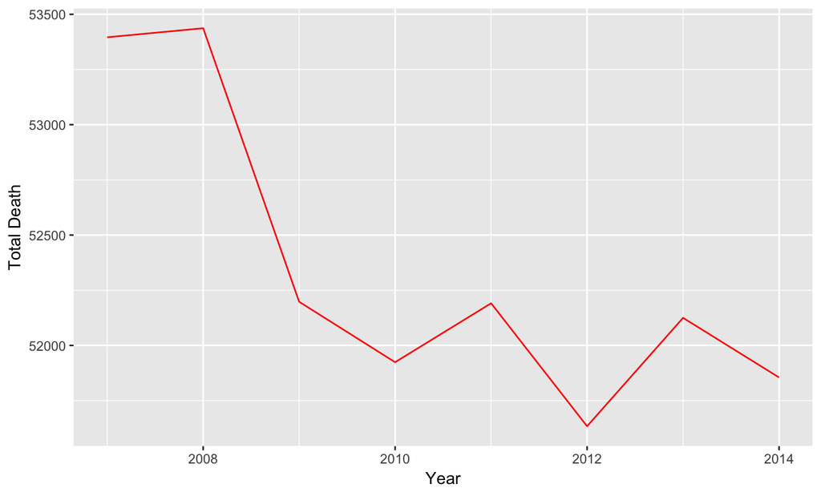

## Major Leading Causes for The Changes in The Trend Overview

**From 2008 to 2009**: Chronic Liver Disease and Cirrhosis, Nephritis, Nephrotic Syndrome and Nephrisis. **From 2011 to 2012**: Mental and Behavioral Disorders due to Accidental Poisoning and Other Psychoactive Substance Use, Human Immunodeficiency Virus Disease.

## Death for Male/Female Overtime

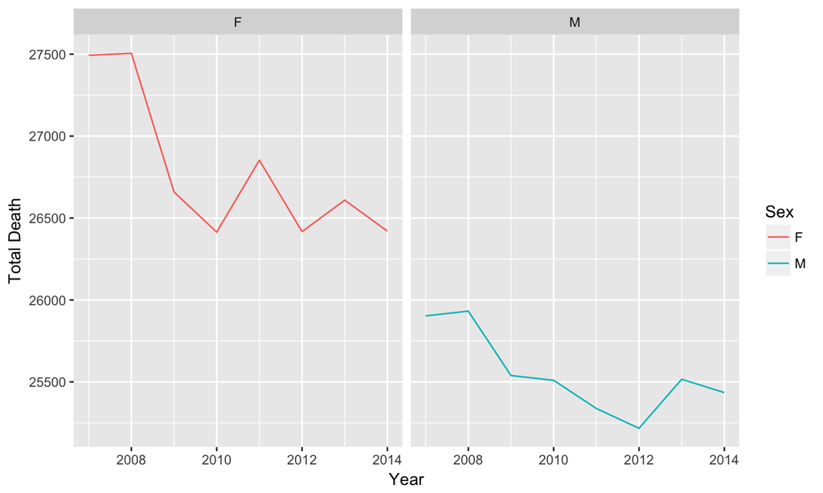

## Major Leading Causes for The Changes in The Trend (Male)

**From 2008 to 2009**: Assault (Homicide). **From 2011 to 2012**: Assault (Homicide), Chronic Lower Respiratory Diseases, Human Immunodeficiency Virus Disease, Influenza (Flu) and Pneumonia, Mental and Behavioral Disorders due to Accidental Poisoning and Other Psychoactive Substance Use.

## Major Leading Causes for The Changes in The Trend (Female)

**From 2008 to 2009**: Chronic Liver Disease and Cirrhosis, Nephritis, Nephrotic Syndrome and Nephrisis. **From 2011 to 2012**: Human Immunodeficiency Virus Disease, Mental and Behavioral Disorders due to Accidental Poisoning and Other Psychoactive Substance Use.

## Death Trend by Race

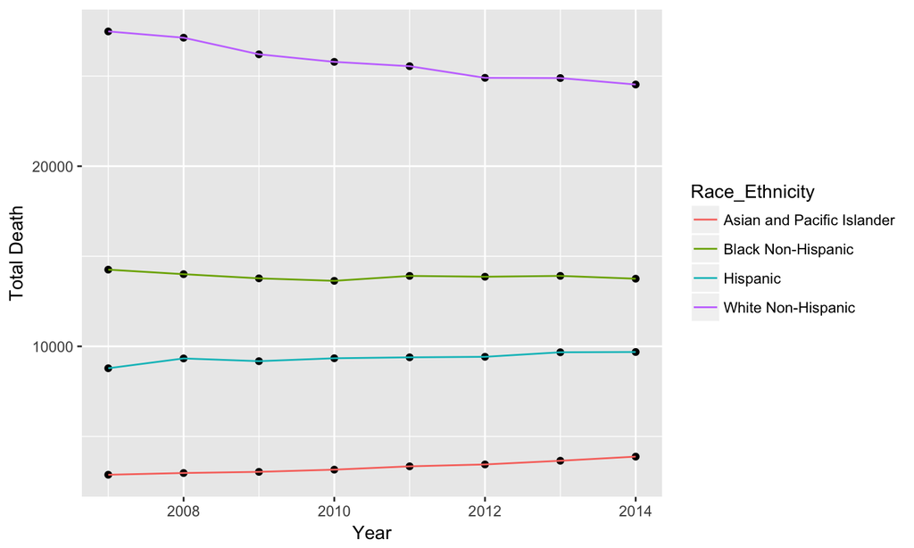

## Death Ranking by Race

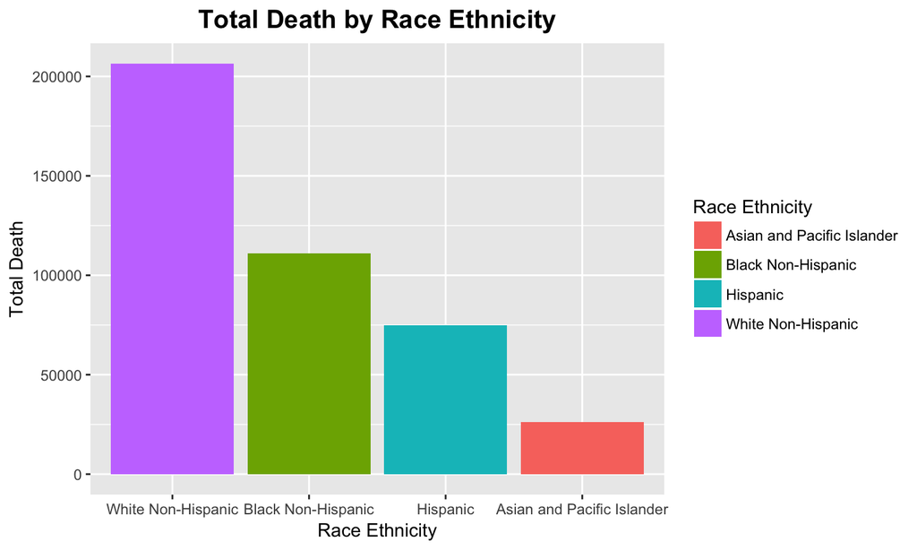

## Top 5 Leading Causes

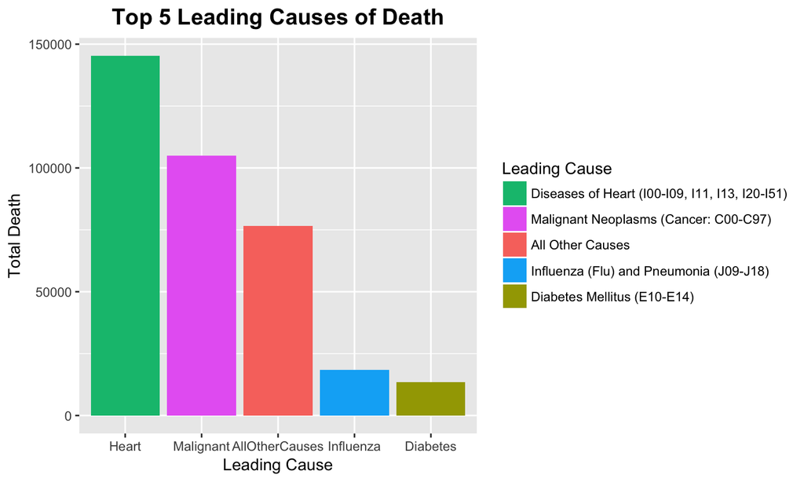